# LSTM Initial data set exploration

Chris Dorich

June 3, 2022

Chris Dorich (chris.dorich@colostate.edu)  
June 3, 2022

# Data upload & management

```
## [1] 79341    22
```

```
## [1] 128
```

```
##     SiteID           Treatment              Date             Fert.Type
##  Length:72720       Length:72720       Min.   :1999-01-01   Length:72720
##  Class :character   Class :character   1st Qu.:2010-01-30   Class :character
##  Mode  :character   Mode  :character   Median :2012-10-15   Mode  :character
##                                        Mean   :2011-08-10
##                                        3rd Qu.:2014-03-04
##                                        Max.   :2018-07-25
##
##  Fertilizer.kgN.ha Tillage.type         Tillage.cm         Sand
##  Min.   :   8.00   Length:72720       Min.   : 5.00   Min.   :18.00
##  1st Qu.:  26.00   Class :character   1st Qu.:15.00   1st Qu.:29.00
##  Median :  38.00   Mode  :character   Median :20.00   Median :31.00
##  Mean   :  84.57                      Mean   :18.12   Mean   :36.74
##  3rd Qu.:  80.00                      3rd Qu.:20.00   3rd Qu.:53.00
##  Max.   :1000.00                      Max.   :30.00   Max.   :66.00
##  NA's   :72487                        NA's   :72640   NA's   :54425
##       Silt            Clay            rain         rain.irrigation
##  Min.   :14.00   Min.   :16.00   Min.   :  0.000   Min.   :  0.00
##  1st Qu.:22.00   1st Qu.:16.00   1st Qu.:  0.000   1st Qu.:  0.00
##  Median :24.00   Median :19.00   Median :  0.000   Median :  0.00
##  Mean   :28.51   Mean   :32.93   Mean   :  2.045   Mean   :  3.53
##  3rd Qu.:24.37   3rd Qu.:55.00   3rd Qu.:  0.600   3rd Qu.:  0.80
##  Max.   :52.00   Max.   :60.00   Max.   :257.900   Max.   :234.00
##  NA's   :54425   NA's   :54425   NA's   :16492     NA's   :64896
##       tavg          soil.temp5      soil.temp10          WFPS
##  Min.   :-34.22   Min.   :-11.69   Min.   :-10.89   Min.   :  0.00
##  1st Qu.:  1.50   1st Qu.:  0.20   1st Qu.:  8.54   1st Qu.: 37.35
##  Median : 12.65   Median : 10.01   Median : 14.91   Median : 50.02
##  Mean   :  9.49   Mean   :  9.73   Mean   : 14.36   Mean   : 49.94
##  3rd Qu.: 19.12   3rd Qu.: 16.91   3rd Qu.: 20.98   3rd Qu.: 63.80
##  Max.   : 35.90   Max.   : 40.00   Max.   : 45.90   Max.   :114.50
##  NA's   :34873    NA's   :44169    NA's   :31278    NA's   :30221
##    wfps.calc           NH4              NO3              n2o
##  Min.   :  0.00   Min.   :  0.00   Min.   :  0.00   Min.   : -52.784
##  1st Qu.: 37.35   1st Qu.:  2.23   1st Qu.:  3.62   1st Qu.:   0.246
##  Median : 50.02   Median :  6.68   Median :  9.29   Median :   1.414
##  Mean   : 49.94   Mean   : 12.98   Mean   : 22.47   Mean   :  12.319
##  3rd Qu.: 63.80   3rd Qu.: 13.51   3rd Qu.: 24.51   3rd Qu.:   5.785
##  Max.   :114.51   Max.   :387.96   Max.   :337.21   Max.   :2585.230
##  NA's   :30221    NA's   :71288    NA's   :71289    NA's   :18907
##      n2osd            Crop                year
##  Min.   :  0.00   Length:72720       Min.   :1999
##  1st Qu.:  0.54   Class :character   1st Qu.:2010
##  Median :  3.27   Mode  :character   Median :2012
##  Mean   :  7.87                      Mean   :2011
##  3rd Qu.:  8.06                      3rd Qu.:2014
##  Max.   :810.43                      Max.   :2018
##  NA's   :45837
```

Adding tillage and fertilization metrics.  
* Days since last till/fert event.

Find what site-treatments to exclude.  
Excluded site-treatments with missing soil moisture or <40% of days with WFPS measurements:

- WFPS needs more gap-filling than originally thought.
- Will have to exclude these sites from the NN for now I think.

# Gap-filling/interpolation of covariates

Basic linear interpolation for covariates.

## Soil inorganic N decay curves

Decay check points  
* How does NO3/NH4 decay look during the time series

overly simplistic NO3/NH4 decay model…  
* what about the crop needs/existence  
* soil texture  
* what else could be worked in.

Test case looking at WagnerRiddle data:

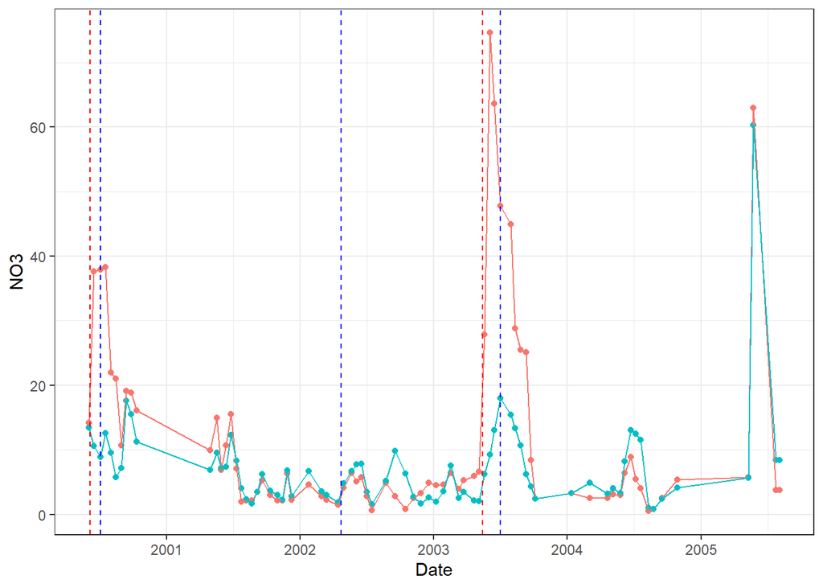

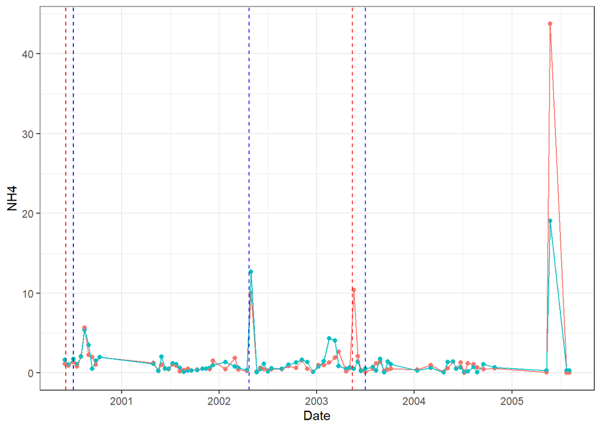

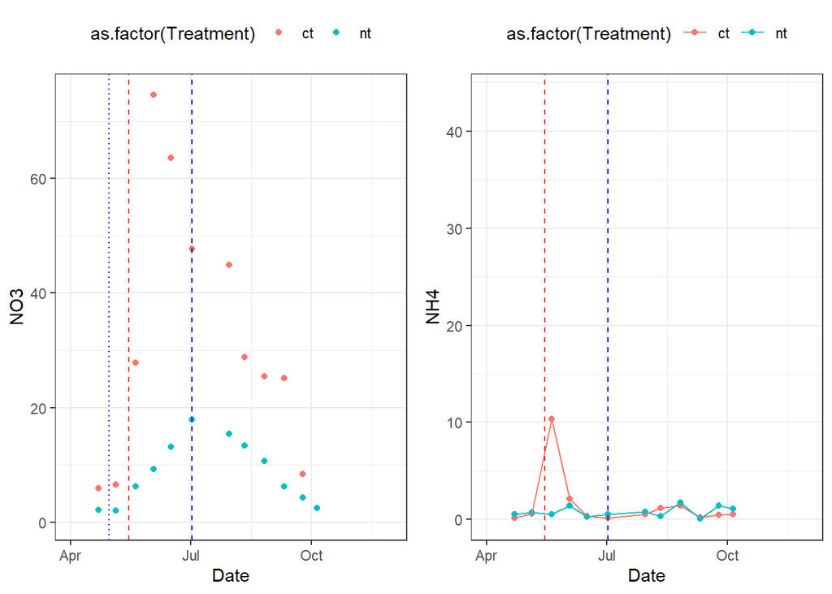

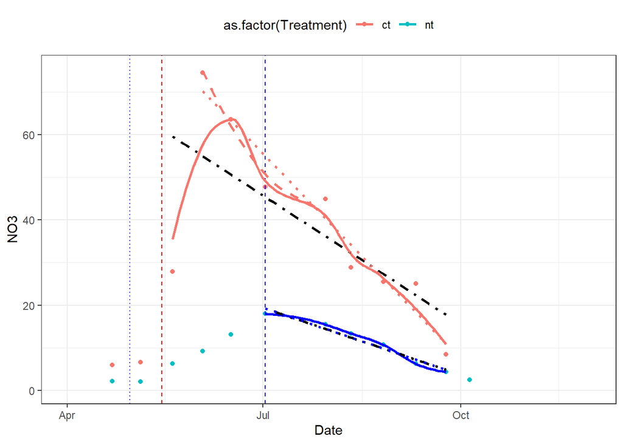

Notes on the figure:  
* The dashed vertical lines are when fertilizer was applied (160 for ct, 60 for nt)  
* The faint blue vertical dash is when red clover was killed at the nt site (explains why NO3 starts increasing shortly after)  
* The dashed lines amongst points are linear regressions from fert date, or from peak NO3.  
* The smoother lines are loess regressions from fert data, or from peak NO3.

Problems with gap-filling on soil inorganic N:  
* NO3 may not peak immediately after fertilization. Hard to determine what the peak would be/when it would occur. * linear regression from fert date (black line for ct) isn’t great. Would overestimate at first, but generally underestimate NO3.  
* Loess and linear regressions (for urea and this site-treatment case) from peak NO3 are fairly similar.

So, what options do we have for interpolation of soil inorganic N?

What about just using a continuous/constant value (the fertilizer.kgN.ha) as we know how much N was applied, and wont introduce our own error from interpolation, just provide another piece of info to the NN (how much N was applied) and see if it can infer/help with the inorganic N and time frame?

Soil inorganic N across sites, by N application type

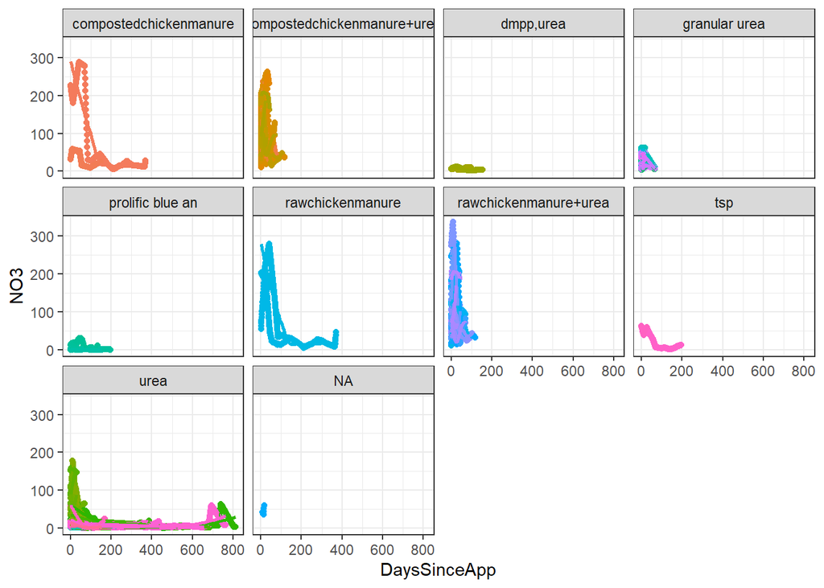

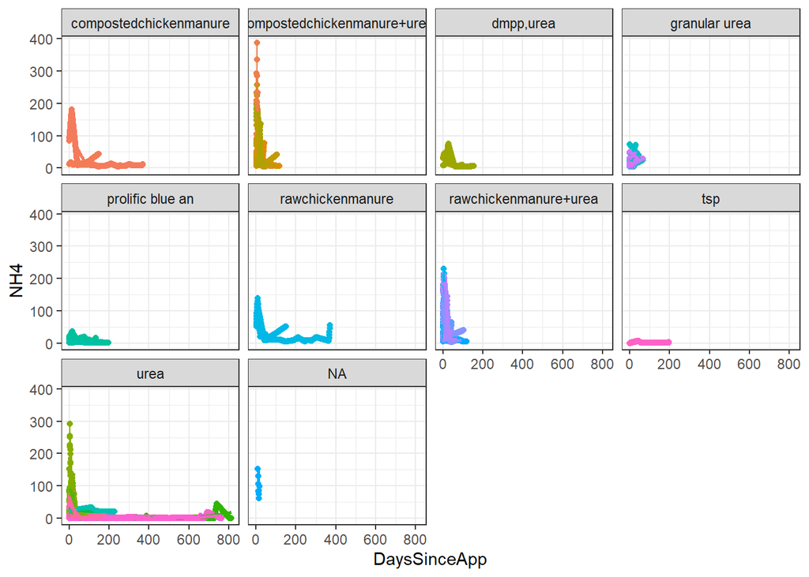

# Site-treatment breakdowns

|  | SiteID | Treatment | year | meanDailyn2o | Annn2o | days | n2ocounts | AnnPrecip | tavg | stemp5 | stemp10 | WFPS | wfps.calc | Fertilizer.kgN.ha | n |
| --- | --- | --- | --- | --- | --- | --- | --- | --- | --- | --- | --- | --- | --- | --- | --- |
| 1 | barton.79 | no.om.no.urea | 2013 | -6.49908645097289 | -2157.696701723 | 365 | 332 | 268.66 |  | 21.4306228373702 | 21.247508650519 | 6.51764102512 | 6.51764102512 | 0 | 365 |
| 2 | barton.79 | no.om.plus.urea | 2013 | -6.23502633741265 | -2070.028744021 | 365 | 332 | 268.66 |  | 21.4306228373702 | 21.247508650519 | 6.0732564096 | 6.0732564096 | 100 | 365 |
| 3 | barton.79 | om.no.urea | 2013 | -4.01110404361212 | -1323.664334392 | 365 | 330 | 268.66 |  | 21.4306228373702 | 21.247508650519 | 7.0360897428 | 7.0360897428 | 40 | 365 |
| 4 | barton.79 | om.plus.urea | 2013 | -4.0046428034006 | -1329.541410729 | 365 | 332 | 268.66 |  | 21.4306228373702 | 21.247508650519 | 7.25828205036 | 7.25828205036 | 140 | 365 |
| 5 | bel.18 | Early.Termination | 2013 | 31.0905852415153 | 8145.733333277 | 306 | 262 | 736.5 |  |  | 13.5130601093344 | 59.2564726027397 | 59.2564726027397 | 0 | 306 |
| 6 | bel.18 | Early.Termination | 2014 | 0.744632768288136 | 43.933333329 | 59 | 59 | 44.2 |  |  | 23.4033898310169 | 11.5418644067797 | 11.5418644067797 | 0 | 59 |
| 7 | bel.18 | Late.Termination | 2013 | 2.38625954466412 | 625.200000702 | 306 | 262 | 736.5 |  |  | 13.5130601737508 | 59.2564726027397 | 59.2564726027397 | 0 | 306 |
| 8 | bel.18 | Late.Termination | 2014 | 0.362146894915254 | 21.3666668 | 59 | 59 | 44.2 |  |  | 23.4033903389831 | 11.5418644067797 | 11.5418644067797 | 0 | 59 |
| 9 | bel.18 | Mowed.Pasture | 2013 | 0.52881679389313 | 138.55 | 306 | 262 | 736.5 |  |  | 13.5130601540984 | 59.2564726027397 | 59.2564726027397 | 0 | 306 |
| 10 | bel.18 | Mowed.Pasture | 2014 | 0.180790955932203 | 10.6666664 | 59 | 59 | 44.2 |  |  | 23.4033903389831 | 11.5418644067797 | 11.5418644067797 | 0 | 59 |

[output cut: 268 more lines]

|  | SiteID | Treatment | meanDailyn2o | Annn2o | AnnPrecip | tavg | stemp5 | stemp10 | WFPS | wfps.calc | n |
| --- | --- | --- | --- | --- | --- | --- | --- | --- | --- | --- | --- |
| 1 | barton.79 | no.om.no.urea | -6.49908645097289 | -2157.696701723 | 268.66 |  | 21.4306228373702 | 21.247508650519 | 6.51764102512 | 6.51764102512 | 365 |
| 2 | barton.79 | no.om.plus.urea | -6.23502633741265 | -2070.028744021 | 268.66 |  | 21.4306228373702 | 21.247508650519 | 6.0732564096 | 6.0732564096 | 365 |
| 3 | barton.79 | om.no.urea | -4.01110404361212 | -1323.664334392 | 268.66 |  | 21.4306228373702 | 21.247508650519 | 7.0360897428 | 7.0360897428 | 365 |
| 4 | barton.79 | om.plus.urea | -4.0046428034006 | -1329.541410729 | 268.66 |  | 21.4306228373702 | 21.247508650519 | 7.25828205036 | 7.25828205036 | 365 |
| 5 | bel.18 | Early.Termination | 15.9176090049017 | 4094.833333303 | 390.35 |  |  | 18.4582249701757 | 35.3991685047597 | 35.3991685047597 | 365 |
| 6 | bel.18 | Late.Termination | 1.37420321978969 | 323.283333751 | 390.35 |  |  | 18.4582252563669 | 35.3991685047597 | 35.3991685047597 | 365 |
| 7 | bel.18 | Mowed.Pasture | 0.354803874912667 | 74.6083332 | 390.35 |  |  | 18.4582252465407 | 35.3991685047597 | 35.3991685047597 | 365 |
| 8 | bel.18 | Spring.Crop | 7.93039513315435 | 2046.16663355 | 390.35 |  |  | 18.4582252465407 | 35.3991685047597 | 35.3991685047597 | 365 |
| 9 | datalibrarian.137 | N000 | 0.262804881574675 | 80.943903525 | 266.4 | 16.6816993464052 |  | 18.8904761904762 | 51.7173509984615 | 51.7173509984615 | 309 |
| 10 | datalibrarian.137 | N040 | 0.500152448876623 | 154.046954254 | 266.4 | 16.6816993464052 |  | 18.8904761904762 | 51.7173509984615 | 51.7173509984615 | 309 |

[output cut: 114 more lines]

Need to deal with the fact that annual emissions are biased towards northern hemisphere, and the dataset is predominantly southern hemisphere.

The LSTM is currently only using continuous rain and WFPS with occasional n2o provided every 5th day, with a sequence length of 30 days.

# Summary statistics

|  | SiteID | Treatment | n2o |
| --- | --- | --- | --- |
| 1 | barton.79 | no.om.no.urea | -2157.697 |
| 2 | barton.79 | no.om.plus.urea | -2070.029 |
| 3 | barton.79 | om.no.urea | -1323.664 |
| 4 | barton.79 | om.plus.urea | -1329.541 |
| 5 | bel.18 | Early.Termination | 8189.667 |
| 6 | bel.18 | Late.Termination | 646.567 |
| 7 | bel.18 | Mowed.Pasture | 149.217 |
| 8 | bel.18 | Spring.Crop | 4092.333 |
| 9 | datalibrarian.137 | N000 | 80.944 |
| 10 | datalibrarian.137 | N040 | 154.047 |

[output cut: 114 more lines]

[figure not shown]

Sum of n2o by covariate bins.

## N2O distribution

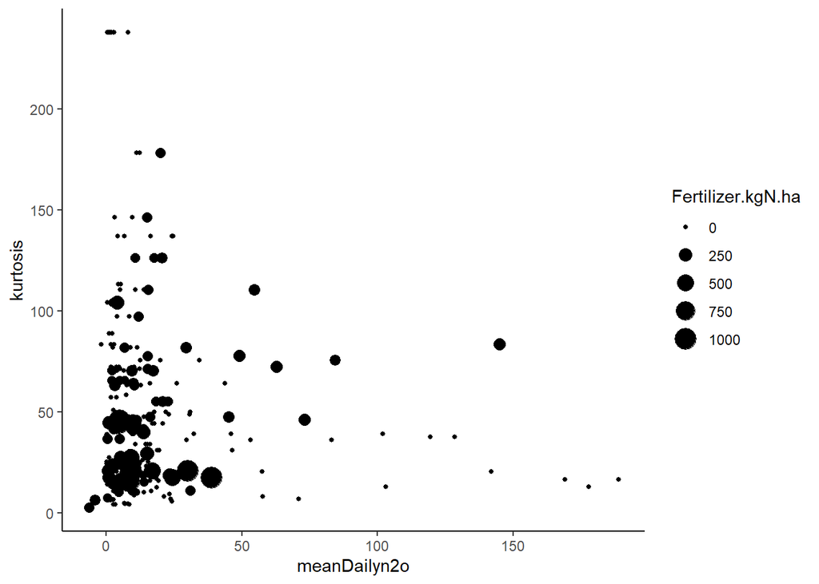

|  | Treatment | squareSkewness | kurtosis | SiteID | year | meanDailyn2o | Annn2o | days | n2ocounts | AnnPrecip | tavg | stemp5 | stemp10 | WFPS | wfps.calc | Fertilizer.kgN.ha | n |
| --- | --- | --- | --- | --- | --- | --- | --- | --- | --- | --- | --- | --- | --- | --- | --- | --- | --- |
| 1 | 0n | 16.1949300521054 | 25.8593172134013 | dougherty.8 | 2014 | 2.17500309161491 | 700.3509955 | 332 | 322 | 714.2 |  |  | 17.2078429771242 | 69.9319171686747 | 69.9319879518072 | 0 | 332 |
| 2 | 100n | 19.5683416099147 | 27.2439781066228 | dougherty.8 | 2014 | 9.09308490652174 | 2927.9733399 | 332 | 322 | 714.2 |  |  | 17.2078429771242 | 69.9319171686747 | 69.9319879518072 | 500 | 332 |
| 3 | 120mm_Irri | 6.14775444317419 | 10.1625846909086 | quayle.33 | 2014 | 13.880487804878 | 1707.3 | 123 | 123 | 185.2 | 20.9276422764228 |  | 22.1037735849057 | 65.47133125 | 65.47133125 | 0 | 123 |
| 4 | 25n | 17.9002986201088 | 23.9642980260157 | dougherty.8 | 2014 | 3.01061155217391 | 969.4169198 | 332 | 322 | 714.2 |  |  | 17.2078429771242 | 69.9319171686747 | 69.9319879518072 | 125 | 332 |
| 5 | 30mm_Irri | 1.59646477444068 | 4.57188429806878 | quayle.33 | 2014 | 6.81707317073171 | 838.5 | 123 | 123 | 185.2 | 20.9276422764228 |  | 22.1415094339623 | 63.8707229169811 | 63.8707229169811 | 0 | 123 |
| 6 | 50n | 18.1496193524286 | 24.6568506474853 | dougherty.8 | 2014 | 4.02061766242236 | 1294.6388873 | 332 | 322 | 714.2 |  |  | 17.2078429771242 | 69.9319171686747 | 69.9319879518072 | 200 | 332 |
| 7 | 60mm_Irri | 4.68374877921229 | 8.46938661557704 | quayle.33 | 2014 | 10.4276422764228 | 1282.6 | 123 | 123 | 185.2 | 20.9276422764228 |  | 21.815 | 54.6906479166981 | 54.6906479166981 | 0 | 123 |
| 8 | 90mm_Irri | 17.906370866381 | 23.2266947003962 | quayle.33 | 2014 | 14.7317073170732 | 1812 | 123 | 123 | 185.2 | 20.9276422764228 |  | 22.9141509433962 | 50.5172375001887 | 50.5172375001887 | 0 | 123 |
| 9 | band | 57.5735523821843 | 75.4014432158558 | francisclar | 2015 | 84.5384394046887 | 12765.304350108 | 271 | 151 | 266.206 | 4.91071428571429 |  | 17.0783269263016 |  |  | 147 | 271 |
| 10 | band | 57.5735523821843 | 75.4014432158558 | francisclar | 2016 | 12.6453859297963 | 682.850840209 | 366 | 54 | 921.247998 | 8.29970967741935 |  |  |  |  | 0 | 366 |

[output cut: 268 more lines]

- skew - measure of the asymmetry of the probability distribution of a real-valued random variable about its mean. skewness for a normal distribution is zero, and any symmetric data should have a skewness near zero. Negative values for the skewness indicate data that are skewed left and positive values for the skewness indicate data that are skewed right.
- kurtosis - measure of the “tailedness” of the probability distribution of a real-valued random variable. High kurtosis tend to have heavy tails, or outliers.  
  [skew and kurtosis info](https://www.itl.nist.gov/div898/handbook/eda/section3/eda35b.htm)

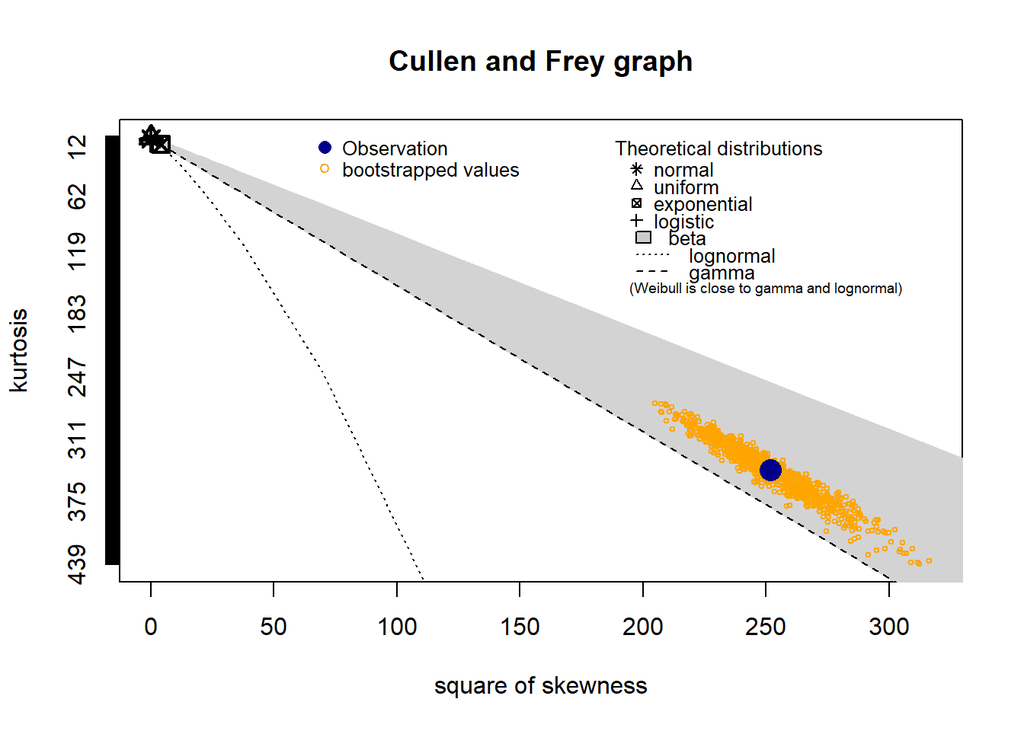

These cullen-frey graphs can be generated for all sites, but gives us an idea of what the distribution of n2o is like.

# Covariate Distributions

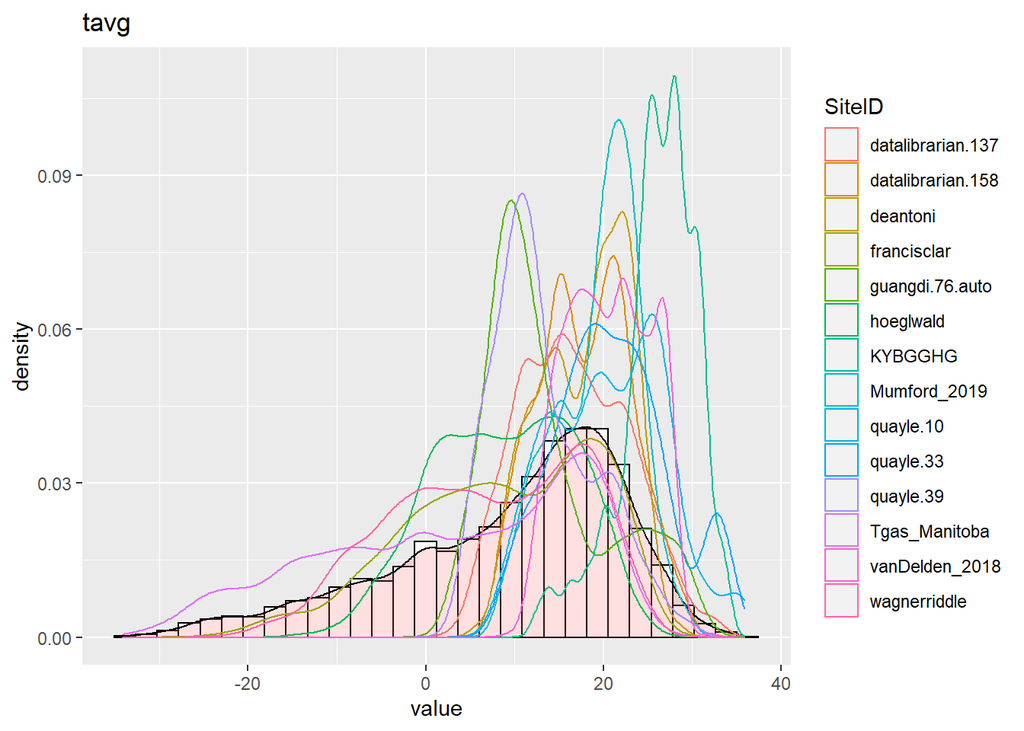

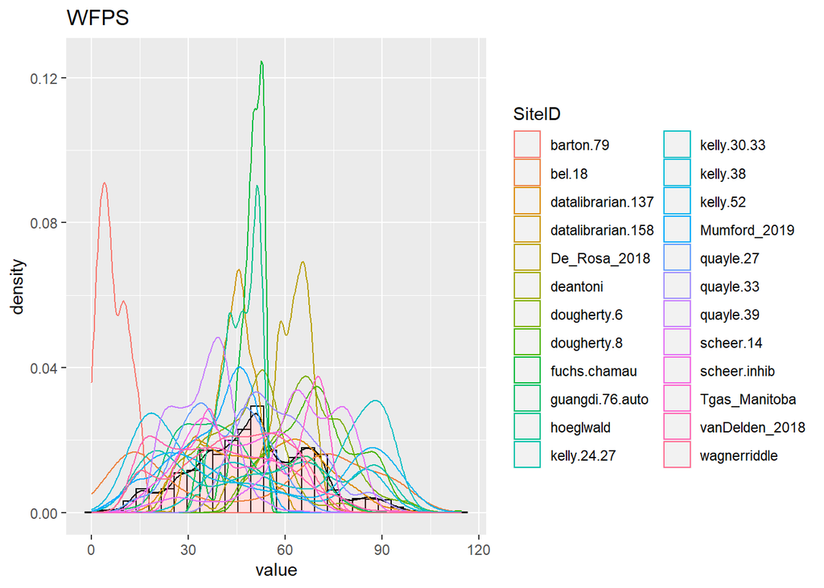

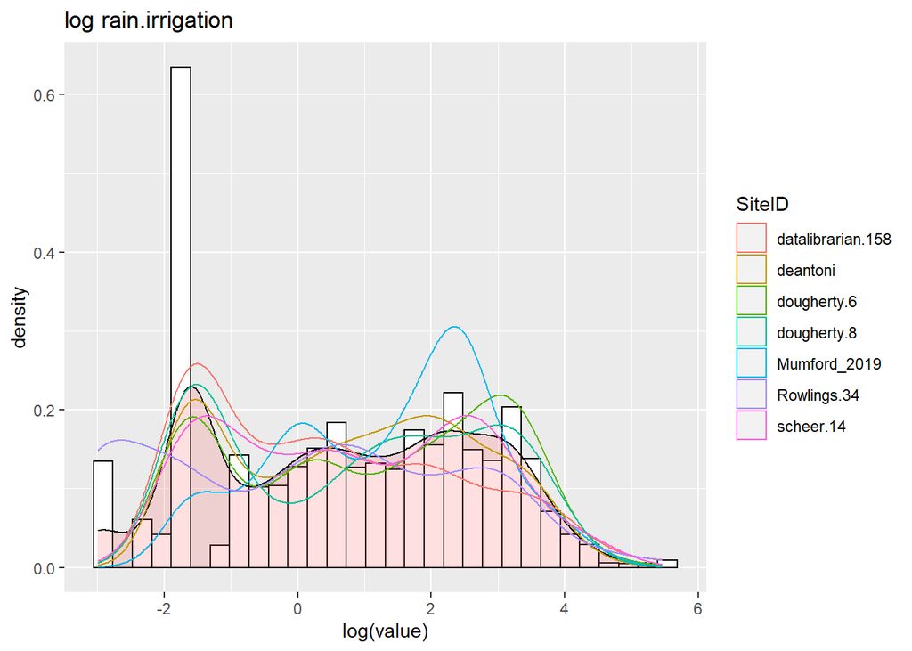

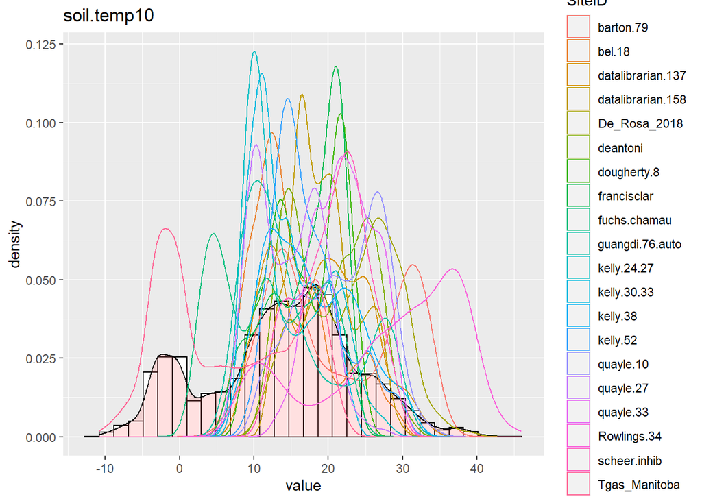

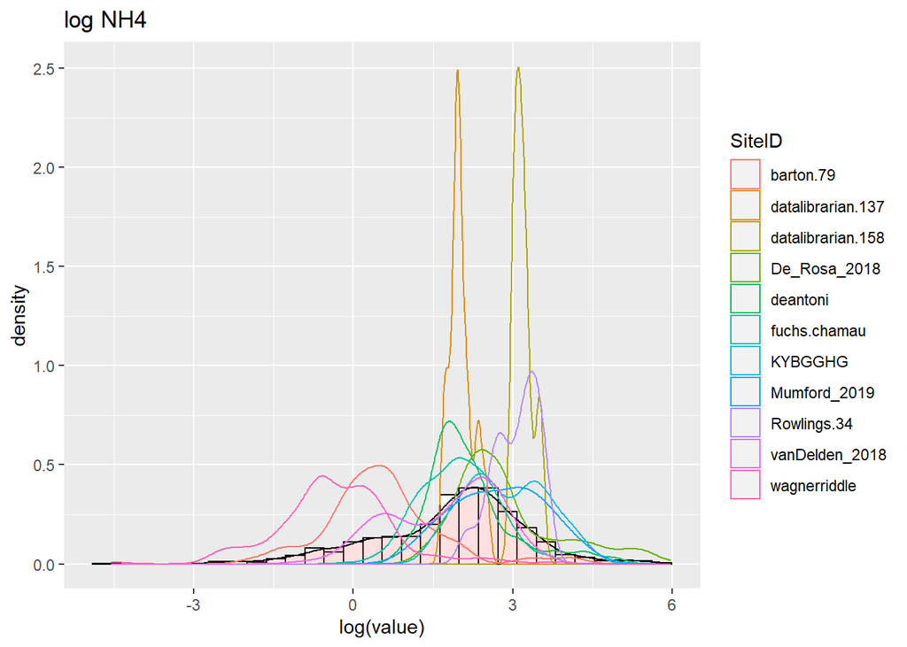

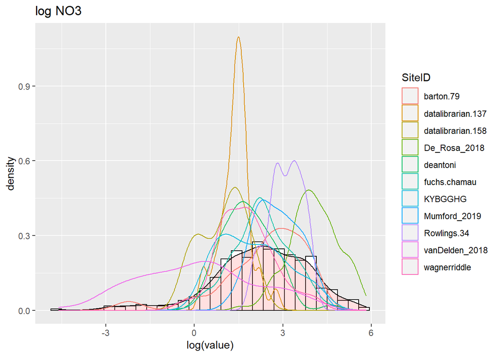

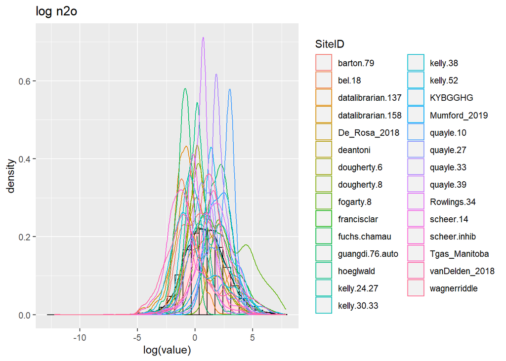

# Covariates examination

on raw, no gap-filling covariates (ie, NA values present in covariates)

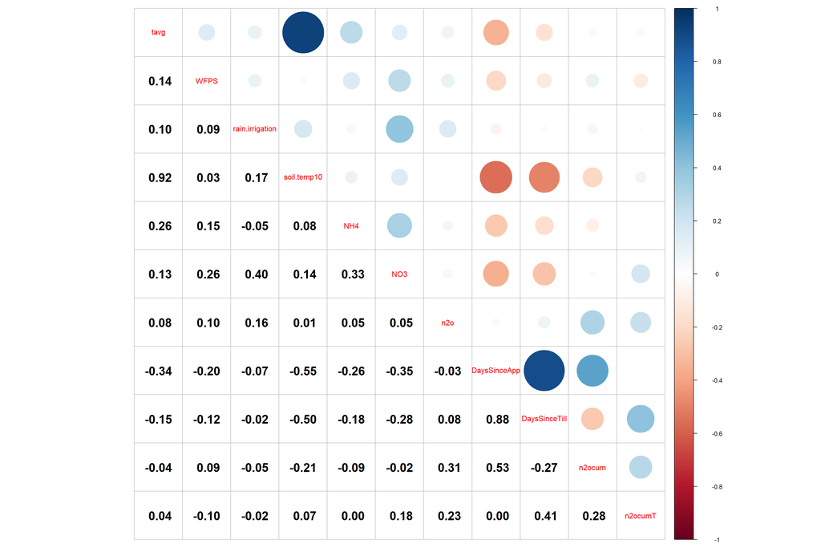

basic linear gap-filled covariate examination

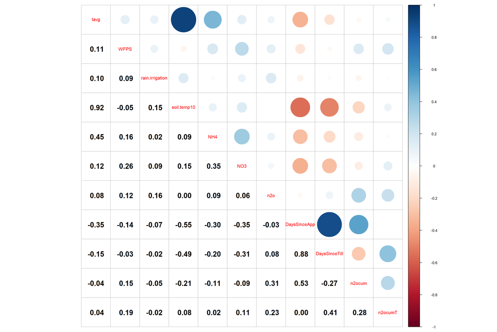

Comparison of raw covariates to n2o (noGF) to a linear interpolated covariates comparison to n2o (GF)

# Variable importance

More on variable importance [here](https://topepo.github.io/caret/variable-importance.html).  
[and here,](https://www.r-bloggers.com/2015/06/variable-importance-plot-and-variable-selection/) [and here](https://cran.r-project.org/web/packages/datarobot/vignettes/VariableImportance.html).

```
##              Overall
## soil.temp10 38.73956
## WFPS        37.94342
## rain        20.15814
## NH4         32.04130
## NO3         41.85826
```

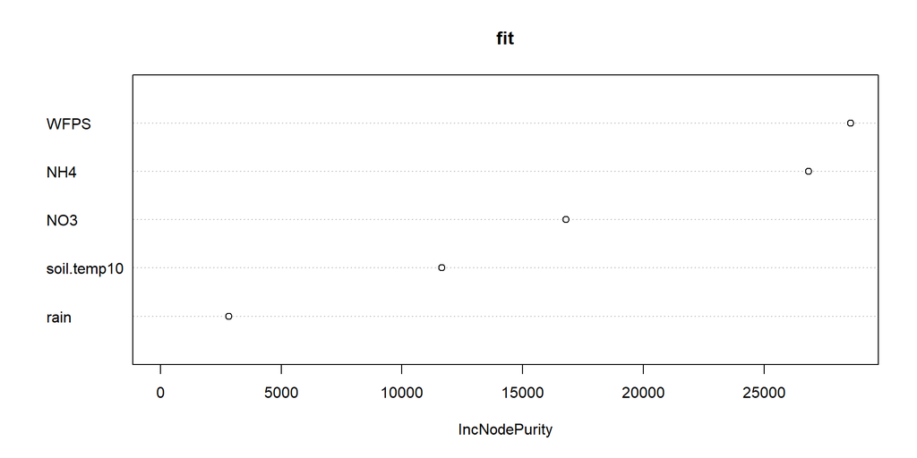

Variable importance from Random Forest test - using raw (no gap-filling data set):

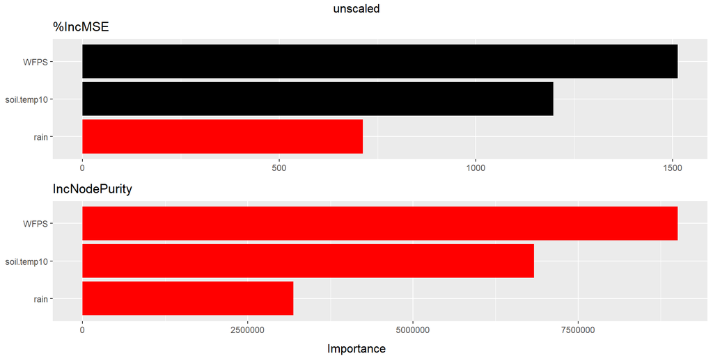

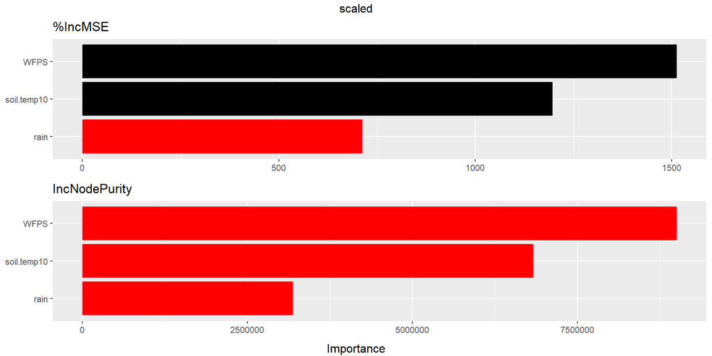

```
##              %IncMSE %IncMSE.pval IncNodePurity IncNodePurity.pval
## WFPS        41.52676   0.00990099       9007074         0.00990099
## rain        39.95415   0.00990099       3189443         0.01980198
## soil.temp10 39.28150   0.00990099       6831913         0.01980198
```

Variable importance from Random Forest using basic linear gap-filling on all covariates:  
* excluded missing n2o values.

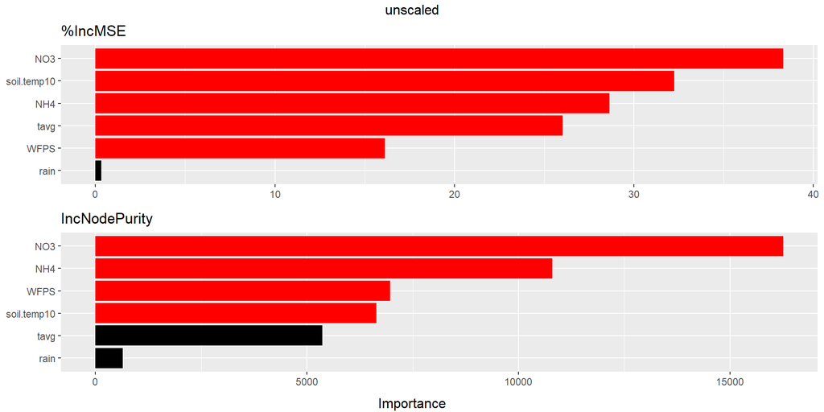

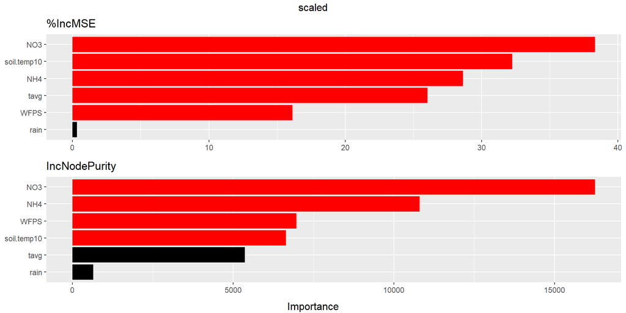

```
##               %IncMSE %IncMSE.pval IncNodePurity IncNodePurity.pval
## NO3         46.051530   0.00990099     16259.518         0.00990099
## WFPS        30.914475   0.00990099      6967.531         0.04950495
## NH4         26.089164   0.00990099     10806.164         0.03960396
## soil.temp10 21.963083   0.00990099      6644.588         0.00990099
## tavg        17.379550   0.06930693      5359.631         0.98019802
## rain         4.743996   0.22772277       650.494         1.00000000
```

# Train-test-holdout data splits

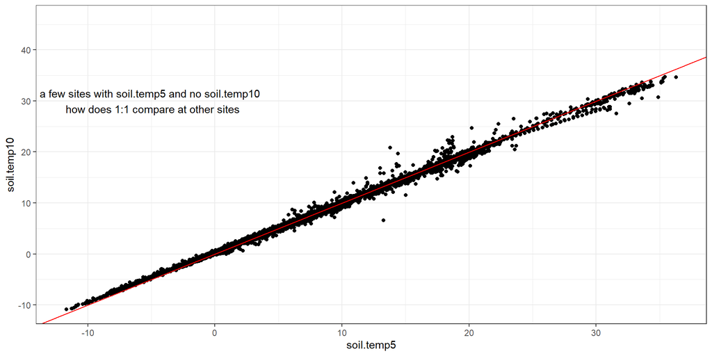

|  | SiteID | Treatment | n | Annn2o | meanDailyn2o | AnnPrecip | stemp10 | WFPS | stemp5 | tavg |
| --- | --- | --- | --- | --- | --- | --- | --- | --- | --- | --- |
| 1 | bel.18 | Early.Termination | 365 | 4094.833333303 | 15.9176090049017 | 390.35 | 18.4582249701757 | 35.3991685047597 |  |  |
| 2 | bel.18 | Late.Termination | 365 | 323.283333751 | 1.37420321978969 | 390.35 | 18.4582252563669 | 35.3991685047597 |  |  |
| 3 | bel.18 | Mowed.Pasture | 365 | 74.6083332 | 0.354803874912667 | 390.35 | 18.4582252465407 | 35.3991685047597 |  |  |
| 4 | bel.18 | Spring.Crop | 365 | 2046.16663355 | 7.93039513315435 | 390.35 | 18.4582252465407 | 35.3991685047597 |  |  |
| 5 | datalibrarian.137 | N000 | 309 | 80.943903525 | 0.262804881574675 | 266.4 | 18.8904761904762 | 51.7173509984615 |  | 16.6816993464052 |
| 6 | datalibrarian.137 | N040 | 309 | 154.046954254 | 0.500152448876623 | 266.4 | 18.8904761904762 | 51.7173509984615 |  | 16.6816993464052 |
| 7 | datalibrarian.137 | N120 | 309 | 251.110301945 | 0.815293188133117 | 266.4 | 18.8904761904762 | 51.7173509984615 |  | 16.6816993464052 |
| 8 | datalibrarian.137 | N200 | 309 | 242.75215001 | 0.788156331201299 | 266.4 | 18.8904761904762 | 51.7173509984615 |  | 16.6816993464052 |
| 9 | datalibrarian.158 | grass.0n | 282 | 132.89 | 2.30905152671756 | 0 | 22.1901507936508 | 46.5844173640167 |  | 20.8059828244275 |
| 10 | datalibrarian.158 | grass.100n | 282 | 715.56 | 7.9258320610687 | 0 | 22.1901507936508 | 46.5844173640167 |  | 20.8059828244275 |

[output cut: 63 more lines]

```
## [1] 73
```

```
## [1] 73
```

# Cross validation training

Rotating holdout datasets for a single model.